# 01.2 Label Hello World Lab

This is the basic building blocks for the Python Tkinter window.

- Contents:
  1. Google Slides Link
  2. Repl.it Link
  3. Lab Overview - What is required.

     a. GUI Solution - This is what the final outcome should look like.

     b. READ.ME File - This is the objectives and rubric.

     c. Build.ME file- This is the code needed to complete the lab.

This lab and Google Slides covers the following content:

- Syntax for defining a window
- Tkinter Library import
- Tk() class instance
- .geometry method
- .title method
- .mainloop method

# 1. Google Slides

[01.2 Label Widget](https://docs.google.com/presentation/d/1B7aTItCdLv2iqlJViUlE2mhdm2WPPhlXKK4V8MWhoCI/edit?usp=sharing)

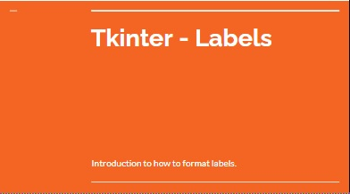

# 01.2 Label Hello World Repl.it

[Tkinter Label Widget Repl](https://replit.com/join/yjfjevqv-erniedrumm)

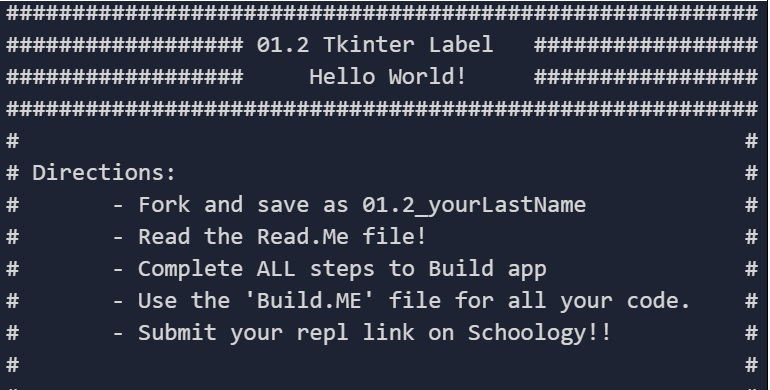

Top

# 3. Lab 01.2 Overview

- Use Build.ME file to construct main.py file.
- Change Label text
- Modify window size: height=500 and width=450

## a. GUI Solution for 01.2 Label HelloWorld Lab

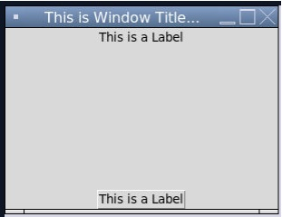

Top

## b. The 'READ.ME' File

### This is a required read through because this file includes the directions, steps, objectives, point values, and rubric.

```python
#########################################################
################## 01.2 Tkinter Label   #################
##################     Hello World!     #################
#########################################################
#                                                       #
# Directions:                                           #
#       - Fork and save as 01.2_yourLastName            #
#       - Read the Read.Me file!                        #
#       - Complete ALL steps to Build app               #
#       - Use the 'Build.ME' file for all your code.    #
#       - Submit your repl link on Schoology!!          #
#                                                       #
#  --------------------------------------------------   #
# Essential Setup Steps:                                #
#     Setup: Enter comments for Name, Date, Lab desc.   #
#     1. import * (ALL) the tkinter libraries           #
#     2. The Tk() class instance                        #
#     3. The .geometry method                           #
#     4. The .title method                              #
#     5. The .mainloop method                           #
#                                                       #
#  --------------------------------------------------   #
# Objectives:                                           #
#      1. Use Build.ME file to construct main.py file.  #
#           Include proper formatting and comments.     #
#      2. Change Label text                             #
#      3. Add additional label                          #
#      4. Modify window size                            #
#                                                       #
#  --------------------------------------------------   #
# New Python Content:                                   #
#           Labels                                      #
#           Label Parameters                            #
#                                                       #
#  --------------------------------------------------   #
# Point Values:                                         #
#        Comments:                                      #
#                   name, date, description   5         #
#                                                       #
#        Runs as intended:                    5         #
#                                                       #
#        Change Label text:                   5         #
#                                                       #
#        Add additional label:               10         #
#                                                       #
#        Window size=Height=500, Widgh=450:   5         #
#                                                       #
#                                            30 Total   #
#                                                       #
#  --------------------------------------------------   #
#  Rubric:                                              #
#                                                       #
#      Update Comments                                  #
#               0-1           2-3          4-5          #
#          ------------   ------------   ------------   #
#               No         Some           Lots of       #
#            Comments       Comments       comments     #
#               No         Little         Lots of       #
#             Updates        Detail        details      #
#                                         Updated       #
#                                                       #
#                                                       #
#      Runs as Intended                                 #
#              0-1           2-4             5          #
#         ------------   ------------   ------------    #
#         Does not run   Runs with      Runs with no    #
#          or no code     errors or      errors.        #
#          and/or wrong   unexpected    Runs as intended#
#          code.          results.      Additional      #
#                                        features do not#
#                                        effect app     #
#                                                       #
#                                                       #
#      Change Label Text                                #
#              0-1           2-4             5          #
#         ------------   ------------   ------------    #
#         No title or    Spelling       Hello World is  #
#          does not say   issues or      present and    #
#          hello world.   not in         can see in the #
#                         window title   console window #
#                                                       #
#                                                       #
#      Add additional label                             #
#              0-3           4-7            8-10        #
#         ------------   ------------   ------------    #
#         No label added Missing one    Additional label#
#          or not         part or not    works as       #
#          working at     working        intended       #
#          all.           correctly.    No errors.      #
#                         OR incorrect                  #
#                         label text.                   #
#                                                       #
#                                                       #
#                                                       #
#      Window Size changed to Height=500, Width=450     #
#              0-1           2-4             5          #
#         ------------   ------------   ------------    #
#         No changes to  Missing one    Width and Height#
#          the height     of the         created and set#
#          or width in    settings for   correctly.     #
#                         height or                     #
#                         width. OR                     #
#                        Wrong width or                 #
#                         height numbers                #
#                                                       #
#########################################################
```

## c. The 'Build.ME' File

### This file includes all the code necessary to get the lab up and running. It is divided into important sections.

```python
# Objectives.
#   1. Ensure basic window works.
#   2. Add code for both labels.
#   3. Create 1-3 additional Labels.
#   4. Resize window.


# Label 1.
label_1 = Label(root, text="This is a Label")
label_1.pack()

# Label 2.
label_2 = Label(root, text="This is a Label", relief="raised")
label_2.pack(side="bottom")


Resources:
# https://www.tutorialspoint.com/python/tk_label.htm
```

Top

## Resources

#### Sources and deeper learning research:

1. Python Tkinter Canvas Widget. Studytonight Technologies Pvt. Let. 2021. 3/30/2021. https://www.studytonight.com/tkinter/python-tkinter-canvas-widget
1. W3Schools.com - [Python GUI Programming](https://www.w3schools.in/python-tutorial/gui-programming/)
1. RepL.it. https://replit.com/~

Top